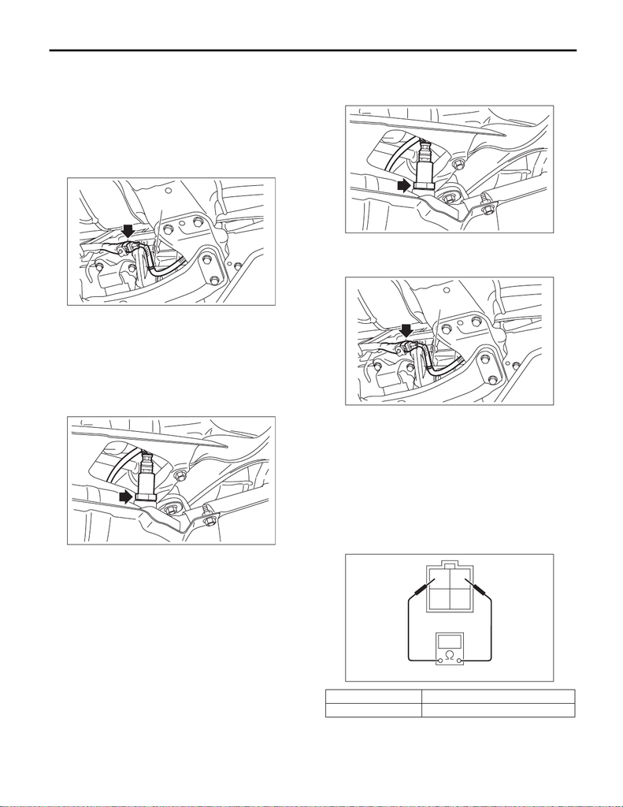

Rear Oxygen Sensor

17.Rear Oxygen Sensor

A: REMOVAL

1) Disconnect the ground cable from battery.

2) Lift up the vehicle.

3) Remove the transmission under cover.

4) Disconnect the connector from the rear oxygen

sensor, and remove the clip (A) holding the rear ox-

ygen sensor harness.

5) Apply spray-type lubricant to the threaded por-

tion of rear oxygen sensor, and leave it for one

minute or more.

6) Remove the rear oxygen sensor.

CAUTION:

When removing the rear oxygen sensor, wait

until exhaust pipe cools, otherwise it will dam-

age the exhaust pipe.

B: INSTALLATION

CAUTION:

If lubricant is spilt onto the exhaust pipe, wipe it

off completely with cloth to avoid emission of

smoke or causing a fire.

1) Before installing rear oxygen sensor, apply the

anti-seize compound only to the threaded portion of

rear oxygen sensor to make the next removal eas-

ier.

CAUTION:

Never apply anti-seize compound to the protec-

tor of rear oxygen sensor.

Anti-seize compound:

NEVER-SEEZ NSN, JET LUBE SS-30 or

equivalent

2) Install the rear oxygen sensor.

Tightening torque:

21 N·m (2.1 kgf-m, 15.5 ft-lb)

3) Connect the connector to the rear oxygen sen-

sor, and hold the rear oxygen sensor harness with

the clip (A).

4) Install the transmission under cover.

Tightening torque:

18 N·m (1.8 kgf-m, 13.3 ft-lb)

5) Lower the vehicle.

6) Connect the battery ground terminal.

C: INSPECTION

1) Check that the rear oxygen sensor has no defor-

mation, cracks or other damages.

2) Measure the resistance between rear oxygen

sensor terminals.

(A)

Terminal No. Standard

1 and 2 5.6

+0.8

–0.6

Ω (when 20°C (68°F))